# REGRESIONES

camila durand

2022-10-08

```r
library(rio)
library(dplyr)
library(stringr)
```

```r
DATA = import("https://raw.githubusercontent.com/CarlosChavarri23/TRABAJO-GRUPAL-POL304/main/DataGRUPAL.csv")
```

```r
colnames(DATA)=c("ISO3", "COUNTRY","MIGRATION", "DESEMPLEO","CRI","PUBLIC_SERV", "CORRUPTION","HUMANRIGTHS","PEACEINDEX","INTERNET", "HAMBRE", "ELECTRICIDAD")
str(DATA)
```

```
## 'data.frame':    211 obs. of  12 variables:
##  $ ISO3        : chr  "ARE" "ARG" "ARG" "ARG" ...
##  $ COUNTRY     : chr  "United Arab Emirates" "Argentina" "Argentina" "Argentina" ...
##  $ MIGRATION   : num  -3.45 -0.08 -0.08 -0.08 -5.36 6.93 6.93 6.93 3.55 3.55 ...
##  $ DESEMPLEO   : num  2.2 9.8 9.8 9.8 18.3 5.2 5.2 5.2 4.5 4.5 ...
##  $ CRI         : num  118 60 60 60 98.2 ...
##  $ PUBLIC_SERV : num  1.6 3.3 3.3 3.3 3.3 1.5 1.5 1.5 1.1 1.1 ...
##  $ CORRUPTION  : num  1.8 1.98 1.98 1.98 2.12 ...
##  $ HUMANRIGTHS : chr  "7,6" "3,9" "3,9" "3,9" ...
##  $ PEACEINDEX  : int  71 45 45 45 42 77 77 77 77 77 ...
##  $ INTERNET    : num  NA 79.9 79.9 79.9 NA ...
##  $ HAMBRE      : num  NA 2140 3317 8261 NA ...
##  $ ELECTRICIDAD: num  NA 0 0 0 NA 0 0 0 0 0 ...
```

REGRESION CAMILA

```r
modelo1=formula(MIGRATION~ DESEMPLEO + CRI + PUBLIC_SERV)
```

```r
reg1=lm(modelo1,data=DATA)
summary(reg1)
```

Call: lm(formula = modelo1, data = DATA)

Residuals: Min 1Q Median 3Q Max -11.1340 -1.2807 -0.1956 1.1656 15.8381

Coefficients: Estimate Std. Error t value Pr(>|t|)  
(Intercept) 3.025887 0.705289 4.290 2.74e-05 DESEMPLEO -0.003472 0.041391 -0.084 0.9332  
CRI -0.011366 0.006213 -1.829 0.0688 .  
PUBLIC_SERV -0.436752 0.071469 -6.111 4.84e-09 — Signif. codes: 0 ‘**’ 0.001 ’**’ 0.01 ’’ 0.05 ‘.’ 0.1 ’ ’ 1

Residual standard error: 2.721 on 207 degrees of freedom Multiple R-squared: 0.1549, Adjusted R-squared: 0.1426 F-statistic: 12.64 on 3 and 207 DF, p-value: 1.273e-07

```r
library(stargazer)
reg1=lm(modelo1,data=DATA)
stargazer(reg1,type = "html",intercept.bottom = FALSE)
```

|  | *Dependent variable:* |
| --- | --- |
|  | MIGRATION |
| Constant | 3.026*** |
|  | (0.705) |
| DESEMPLEO | -0.003 |
|  | (0.041) |
| CRI | -0.011* |
|  | (0.006) |
| PUBLIC_SERV | -0.437*** |
|  | (0.071) |
| Observations | 211 |
| R<sup>2</sup> | 0.155 |
| Adjusted R<sup>2</sup> | 0.143 |
| Residual Std. Error | 2.721 (df = 207) |
| F Statistic | 12.643*** (df = 3; 207) |
| *Note:* | p<0.1; p<0.05; p<0.01 |

REGRESIONES HECTOR

```r
modelo2=formula(MIGRATION~ CORRUPTION)
reg2=lm(modelo2,data=DATA)
summary(reg2)
```

Call: lm(formula = modelo2, data = DATA)

Residuals: Min 1Q Median 3Q Max -11.0330 -1.0990 -0.0020 0.9956 15.3045

Coefficients: Estimate Std. Error t value Pr(>|t|)  
(Intercept) 3.7545 0.7659 4.902 1.90e-06 *CORRUPTION -1.9375 0.3980 -4.868 2.22e-06* — Signif. codes: 0 ‘**’ 0.001 ’**’ 0.01 ’’ 0.05 ‘.’ 0.1 ’ ’ 1

Residual standard error: 2.792 on 209 degrees of freedom Multiple R-squared: 0.1018, Adjusted R-squared: 0.09753 F-statistic: 23.69 on 1 and 209 DF, p-value: 2.224e-06

```r
library(stargazer)
stargazer(reg2,type = "html",intercept.bottom = FALSE)
```

|  | *Dependent variable:* |
| --- | --- |
|  | MIGRATION |
| Constant | 3.754*** |
|  | (0.766) |
| CORRUPTION | -1.938*** |
|  | (0.398) |
| Observations | 211 |
| R<sup>2</sup> | 0.102 |
| Adjusted R<sup>2</sup> | 0.098 |
| Residual Std. Error | 2.792 (df = 209) |
| F Statistic | 23.694*** (df = 1; 209) |
| *Note:* | p<0.1; p<0.05; p<0.01 |

REGRESION CARLOS

```r
modelo3=formula(MIGRATION~ INTERNET + HAMBRE + ELECTRICIDAD)
reg3=lm(modelo3,data=DATA)
summary(reg3)
```

Call: lm(formula = modelo3, data = DATA)

Residuals: Min 1Q Median 3Q Max -6.4142 -0.8846 -0.0195 0.9387 5.6705

Coefficients: Estimate Std. Error t value Pr(>|t|)  
(Intercept) -2.775e+00 5.279e-01 -5.256 4.27e-07 *INTERNET 4.646e-02 7.108e-03 6.536 6.73e-10* HAMBRE -3.204e-05 2.299e-05 -1.393 0.1653  
ELECTRICIDAD 3.178e-08 1.485e-08 2.140 0.0338 *  
— Signif. codes: 0 ‘**’ 0.001 ’**’ 0.01 ’’ 0.05 ‘.’ 0.1 ’ ’ 1

Residual standard error: 2.087 on 174 degrees of freedom (33 observations deleted due to missingness) Multiple R-squared: 0.2306, Adjusted R-squared: 0.2173 F-statistic: 17.38 on 3 and 174 DF, p-value: 6.433e-10

```r
library(stargazer)
stargazer(reg3,type = "html",intercept.bottom = FALSE)
```

|  | *Dependent variable:* |
| --- | --- |
|  | MIGRATION |
| Constant | -2.775*** |
|  | (0.528) |
| INTERNET | 0.046*** |
|  | (0.007) |
| HAMBRE | -0.00003 |
|  | (0.00002) |
| ELECTRICIDAD | 0.00000** |
|  | (0.000) |
| Observations | 178 |
| R<sup>2</sup> | 0.231 |
| Adjusted R<sup>2</sup> | 0.217 |
| Residual Std. Error | 2.087 (df = 174) |
| F Statistic | 17.384*** (df = 3; 174) |
| *Note:* | p<0.1; p<0.05; p<0.01 |

COMPARACION DE MODELOS

```r
library(stargazer)
stargazer(reg1,reg2,reg3, type = "html", title = "Modelos planteadOs",digits = 2, single.row = F,no.space = F,intercept.bottom = FALSE,
          dep.var.caption="Variable dependiente:",
          dep.var.labels="Migracion neta",
          keep.stat = c("n","adj.rsq","ser"),df = F,
          notes.label = "Notas:")
```

**Modelos planteadOs**

|  | Variable dependiente: |  |  |
| --- | --- | --- | --- |
|  | Migracion neta |  |  |
|  | (1) | (2) | (3) |
| Constant | 3.03*** | 3.75*** | -2.77*** |
|  | (0.71) | (0.77) | (0.53) |
| DESEMPLEO | -0.003 |  |  |
|  | (0.04) |  |  |
| CRI | -0.01* |  |  |
|  | (0.01) |  |  |
| PUBLIC_SERV | -0.44*** |  |  |
|  | (0.07) |  |  |
| CORRUPTION |  | -1.94*** |  |
|  |  | (0.40) |  |
| INTERNET |  |  | 0.05*** |
|  |  |  | (0.01) |
| HAMBRE |  |  | -0.0000 |
|  |  |  | (0.0000) |
| ELECTRICIDAD |  |  | 0.0000** |
|  |  |  | (0.00) |
| Observations | 211 | 211 | 178 |
| Adjusted R<sup>2</sup> | 0.14 | 0.10 | 0.22 |
| Residual Std. Error | 2.72 | 2.79 | 2.09 |
| Notas: | p<0.1; p<0.05; p<0.01 |  |  |

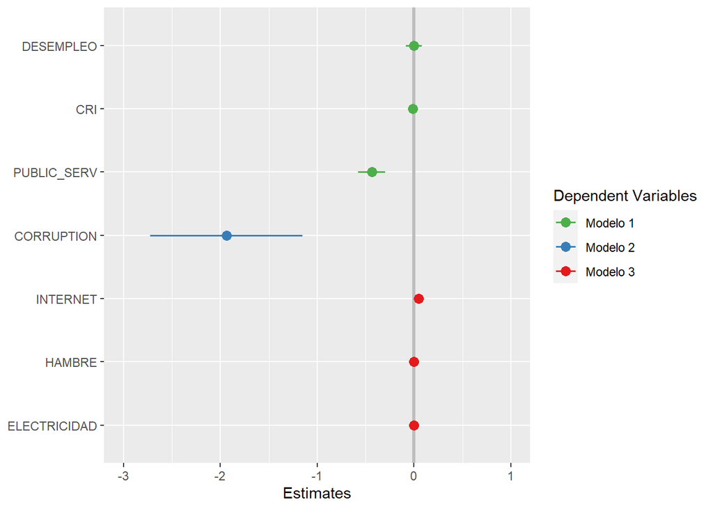

```r
library(ggplot2)
library(sjPlot)
plot_models(reg1,reg2,reg3,vline.color = "grey",m.labels=c("Modelo 1","Modelo 2","Modelo 3"))
```

SE puede ver el efecto de cada avriable independiente en nuetra variable dependiente y su significancia a traves de los modelos